# Trabajo Práctico Nro.2: Aplicación y Análisis de Least Angle Regression (LARS)

Enfoque Estadístico del Aprendizaje

Baldaseroni,Esteban; Conde, M. Cecilia, Lopez, Juan Jose

10/12/2024

# 1. Configuraciones Generales de R

```r
require("knitr")
knitr::opts_chunk$set(echo = TRUE)
# indica desde dónde instalar paquetes
options(repos = c(CRAN = "http://cran.rstudio.com"))
```

```r
# Seteo de directorio de trabajo
setwd("C:/Users/mconde/Documents/EEA-Tps/LARS")
```

```r
#librerías
library(tidyverse)
library(tidymodels)
library(dplyr)
library(kableExtra)
library(readxl)
library(stats)
library(BSDA)
library(ggplot2)
library(reshape2) #correlacion calor
library(GGally)
library(robustbase)
library(knitr)
library(lars) #especifica de lars
library(caret) # ver para qu esirve
library(glmnet) #modelo lasso
library(corrplot)
library(broom)
library(cowplot)
```

# 2. Lectura de Datos y armado de dataset de análisis.

En esta investigación, se utilizará LARS para seleccionar las variables relevantes en el modelo de emisiones de CO2 de países latinoamericanos, comparándolo con otros métodos como el Lasso. LARS fue elegido por su eficacia en la selección de variables en datasets con alta dimensionalidad y posibles colinealidades entre variables.

Se utilizará un dataset disponible públicamente de Kaggle “[Agri-food CO2 emission dataset - Forecast](https://www.kaggle.com/datasets/alessandrolobello/agri-food-co2-emission-dataset-forecasting-ml)” que contiene múltiples variables relevantes para el análisis provenientes de la fusión de datos de Food and Agriculture Organization (FAO) y el Intergovernmental Panel of Climate Change (IPCC), desde el año 1990 hasta el 2020, para diferentes países del mundo.

El dataset se encuentra limpio y preprocesado, por lo que se filtrarán los países relevantes para nuestro estudio. A continuación se procederá con un breve análisis exploratorio y además, se normalizarán los datos para asegurar que todas las variables estén en la misma escala.

**Estructura del dataset orginal**: El dataset consta de 6965 filas y 31 columnas. Incluye diversas variables que permiten realizar análisis detallados sobre las emisiones de CO2 y su relación con el sector agroalimentario.

```r
#Leer datos
df<-read.csv("Agrofood_co2_emission.csv")
names(df)[31] <- "Average.Temperature"
```

```r
# Crear un vector con los países de Sudamérica
paises_sudamerica <- c("Argentina", "Bolivia", "Brazil", "Chile", "Colombia",
                       "Ecuador", "Guyana", "Paraguay", "Peru", "Suriname",
                       "Uruguay", "Venezuela")

# Ver la lista de países
print(paises_sudamerica)
```

```
##  [1] "Argentina" "Bolivia"   "Brazil"    "Chile"     "Colombia"  "Ecuador"
##  [7] "Guyana"    "Paraguay"  "Peru"      "Suriname"  "Uruguay"   "Venezuela"
```

```r
# Filtrar el data frame por los países de Sudamérica
df_sudamerica <- df %>%
  filter(Area %in% paises_sudamerica)
head(df_sudamerica)
```

|  | Area | Year | Savanna.fires | Forest.fires | Crop.Residues | Rice.Cultivation | Drained.organic.soils..CO2. | Pesticides.Manufacturing | Food.Transport | Forestland | Net.Forest.conversion | Food.Household.Consumption | Food.Retail | On.farm.Electricity.Use | Food.Packaging | Agrifood.Systems.Waste.Disposal | Food.Processing | Fertilizers.Manufacturing | IPPU | Manure.applied.to.Soils | Manure.left.on.Pasture | Manure.Management | Fires.in.organic.soils | Fires.in.humid.tropical.forests | On.farm.energy.use | Rural.population | Urban.population | Total.Population...Male | Total.Population...Female | … |
| --- | --- | --- | --- | --- | --- | --- | --- | --- | --- | --- | --- | --- | --- | --- | --- | --- | --- | --- | --- | --- | --- | --- | --- | --- | --- | --- | --- | --- | --- | --- |
| 1 | Argentina | 1990 | 2779.692 | 1097.178 | 1965.499 | 914.3008 | 5128.514 | 689 | 2920.126 | -40102.73 | 81523.29 | 3033.822 | 1210.3655 | 152.0622 | 54.0057 | 8503.606 | 2944.795 | 1143.073 | 6469.846 | 952.7475 | 24131.97 | 2173.349 | 0 | 541.3267 | 6077.228 | 4260175 | 28469564 | 16063515 | 16574141 | … |
| 2 | Argentina | 1991 | 2779.692 | 1097.178 | 2144.235 | 676.3176 | 5128.514 | 699 | 3143.701 | -40102.73 | 81523.29 | 2767.644 | 1047.9432 | 177.6963 | 55.4662 | 8798.837 | 2929.310 | 1139.232 | 6707.110 | 923.2520 | 23840.81 | 2148.927 | 0 | 541.3267 | 4813.008 | 4206419 | 28987499 | 16298168 | 16807594 | … |
| 3 | Argentina | 1992 | 2779.692 | 1097.178 | 2248.566 | 1103.0880 | 5128.514 | 631 | 3514.505 | -40102.73 | 81523.29 | 2929.393 | 982.4031 | 138.1414 | 59.0844 | 9051.402 | 2995.283 | 1117.835 | 5164.660 | 914.2624 | 24040.66 | 2184.396 | 0 | 541.3267 | 6846.902 | 4192854 | 29462297 | 16529209 | 17039077 | … |
| 4 | Argentina | 1993 | 2779.692 | 1097.178 | 2235.483 | 1094.8560 | 5128.514 | 571 | 3733.810 | -40102.73 | 81523.29 | 2981.181 | 968.5174 | 126.2214 | 44.9673 | 9272.754 | 2979.677 | 1093.160 | 5427.016 | 958.3982 | 23395.07 | 2177.431 | 0 | 541.3267 | 7553.773 | 4177901 | 29933016 | 16757748 | 17269492 | … |
| 5 | Argentina | 1994 | 2779.692 | 1097.178 | 2233.539 | 1108.1056 | 5128.514 | 693 | 3935.743 | -40102.73 | 81523.29 | 3031.352 | 875.2937 | 137.9826 | 46.6455 | 9486.868 | 2979.677 | 1108.555 | 5737.828 | 1025.7309 | 23504.47 | 2241.324 | 0 | 541.3267 | 8927.248 | 4160961 | 30397154 | 16989567 | 17499129 | … |
| 6 | Argentina | 1995 | 2779.692 | 1097.178 | 2404.908 | 1443.4616 | 5138.312 | 872 | 4168.870 | -40102.73 | 81523.29 | 3128.939 | 866.0811 | 144.7782 | 279.8729 | 9776.670 | 2128.312 | 1102.449 | 5370.535 | 1019.3587 | 23138.20 | 2200.746 | 0 | 541.3267 | 9032.746 | 4141986 | 30852828 | 17220607 | 17725502 | … |

# 3. EDA

Estructura de dataset del estudio: Se incluye los paises de sudamerica reducionedo la cantidad de registros a 310.

```r
# Resumen estadístico de las variables numéricas:
summary(df_sudamerica)
```

```
##      Area                Year      Savanna.fires       Forest.fires
##  Length:310         Min.   :1990   Min.   :    0.13   Min.   :    0.00
##  Class :character   1st Qu.:1997   1st Qu.:   15.26   1st Qu.:   10.25
##  Mode  :character   Median :2005   Median :   35.90   Median :  122.32
##                     Mean   :2005   Mean   : 1711.73   Mean   : 1500.97
##                     3rd Qu.:2013   3rd Qu.: 1601.88   3rd Qu.:  514.04
##                     Max.   :2020   Max.   :23503.32   Max.   :27663.50
##
##  Crop.Residues      Rice.Cultivation  Drained.organic.soils..CO2.
##  Min.   :   10.12   Min.   :  41.94   Min.   :   0.0
##  1st Qu.:  123.65   1st Qu.: 466.31   1st Qu.: 101.6
##  Median :  215.30   Median :1301.58   Median : 444.0
##  Mean   : 1358.54   Mean   :1704.00   Mean   :1079.4
##  3rd Qu.:  432.57   3rd Qu.:2331.29   3rd Qu.:1000.4
##  Max.   :13452.46   Max.   :8525.13   Max.   :5231.4
##
##  Pesticides.Manufacturing Food.Transport        Forestland
##  Min.   :   0.00          Min.   :    5.024   Min.   :-519221.8
##  1st Qu.:  17.25          1st Qu.:  272.509   1st Qu.: -27952.3
##  Median : 166.00          Median : 1171.260   Median :  -5283.8
##  Mean   :1057.78          Mean   : 3126.688   Mean   : -52107.2
##  3rd Qu.: 844.75          3rd Qu.: 2836.303   3rd Qu.:   -333.7
##  Max.   :7868.00          Max.   :27613.212   Max.   :      0.0
##
##  Net.Forest.conversion Food.Household.Consumption  Food.Retail
##  Min.   :      0       Min.   :   24.79           Min.   :    0.428
##  1st Qu.:   3174       1st Qu.:  130.76           1st Qu.:   43.461
##  Median :  39973       Median : 1324.98           Median :  238.743
##  Mean   : 160051       Mean   : 2951.17           Mean   : 1543.880
##  3rd Qu.:  83135       3rd Qu.: 3128.65           3rd Qu.: 1181.084
##  Max.   :1605106       Max.   :21635.80           Max.   :16052.582
##
##  On.farm.Electricity.Use Food.Packaging     Agrifood.Systems.Waste.Disposal
##  Min.   :   0.025        Min.   :   0.072   Min.   :   72.74
##  1st Qu.:   9.984        1st Qu.:  67.631   1st Qu.: 1053.75
##  Median :  94.234        Median : 129.673   Median : 4163.99
##  Mean   : 354.136        Mean   : 673.512   Mean   :11891.06
##  3rd Qu.: 302.517        3rd Qu.: 638.874   3rd Qu.:10296.70
##  Max.   :4346.010        Max.   :5695.639   Max.   :90686.73
##
```

[output cut: 25 more lines]

```
##  Min.   :  139739   Min.   :   197762   Min.   :   205650
##  1st Qu.:  542223   1st Qu.:  2923365   1st Qu.:  1600148
##  Median : 3131420   Median : 11075220   Median :  7581947
##  Mean   : 6454106   Mean   : 27011265   Mean   : 16516431
##  3rd Qu.: 6970413   3rd Qu.: 30281120   3rd Qu.: 18031028
##  Max.   :38948117   Max.   :186217070   Max.   :104779288
##
##  Total.Population...Female total_emission    Average.Temperature
##  Min.   :   207106         Min.   : -56242   Min.   :-0.4288
##  1st Qu.:  1718671         1st Qu.:   9372   1st Qu.: 0.4054
##  Median :  7625122         Median :  51903   Median : 0.7048
##  Mean   : 16851668         Mean   : 168506   Mean   : 0.7139
##  3rd Qu.: 18397319         3rd Qu.: 126580   3rd Qu.: 1.0007
##  Max.   :108417015         Max.   :1522722   Max.   : 1.7967
##
```

```r
#Dimensiones del dataset (filas y columnas):
dim(df_sudamerica)
```

```
## [1] 310  31
```

```r
# Verificar datos faltantes
missing_data <- sapply(df_sudamerica, function(x) sum(is.na(x)))
print(missing_data)
```

```
##                            Area                            Year
##                               0                               0
##                   Savanna.fires                    Forest.fires
##                               0                               0
##                   Crop.Residues                Rice.Cultivation
##                               0                               0
##     Drained.organic.soils..CO2.        Pesticides.Manufacturing
##                               0                               0
##                  Food.Transport                      Forestland
##                               0                               0
##           Net.Forest.conversion      Food.Household.Consumption
##                               0                               0
##                     Food.Retail         On.farm.Electricity.Use
##                               0                               0
##                  Food.Packaging Agrifood.Systems.Waste.Disposal
##                               0                               0
##                 Food.Processing       Fertilizers.Manufacturing
##                               0                               0
##                            IPPU         Manure.applied.to.Soils
##                               0                               0
##          Manure.left.on.Pasture               Manure.Management
##                               0                               0
##          Fires.in.organic.soils Fires.in.humid.tropical.forests
##                               0                               0
##              On.farm.energy.use                Rural.population
##                              31                               0
##                Urban.population         Total.Population...Male
##                               0                               0
##       Total.Population...Female                  total_emission
##                               0                               0
##             Average.Temperature
##                               0
```

```r
# Filtrar registros donde cualquier columna tiene NA,
df_con_na <- df_sudamerica %>%
  filter(if_any(everything(), is.na))
head(df_con_na)
```

|  | Area | Year | Savanna.fires | Forest.fires | Crop.Residues | Rice.Cultivation | Drained.organic.soils..CO2. | Pesticides.Manufacturing | Food.Transport | Forestland | Net.Forest.conversion | Food.Household.Consumption | Food.Retail | On.farm.Electricity.Use | Food.Packaging | Agrifood.Systems.Waste.Disposal | Food.Processing | Fertilizers.Manufacturing | IPPU | Manure.applied.to.Soils | Manure.left.on.Pasture | Manure.Management | Fires.in.organic.soils | Fires.in.humid.tropical.forests | On.farm.energy.use | Rural.population | Urban.population | Total.Population...Male | Total.Population...Female | … |
| --- | --- | --- | --- | --- | --- | --- | --- | --- | --- | --- | --- | --- | --- | --- | --- | --- | --- | --- | --- | --- | --- | --- | --- | --- | --- | --- | --- | --- | --- | --- |
| 1 | Paraguay | 1990 | 1573.815 | 880.8791 | 183.3180 | 133.2800 | 0 | 44 | 195.0879 | -333.7277 | 42365.81 | 83.9572 | 0.4290 | 0.0253 | 67.63137 | 1412.173 | 209.5877 | 356.491 | 264.8905 | 272.3140 | 3452.806 | 527.6718 | 0 | 478.6893 | NA | 2161900 | 2051842 | 2052617 | 2006578 | … |
| 2 | Paraguay | 1991 | 1573.815 | 880.8791 | 123.2716 | 41.9440 | 0 | 44 | 196.5430 | -333.7277 | 42365.81 | 87.9040 | 0.4345 | 0.0431 | 67.63137 | 1440.426 | 209.5877 | 356.491 | 263.0249 | 275.3493 | 3178.892 | 516.3371 | 0 | 478.6893 | NA | 2185944 | 2137466 | 2107809 | 2060188 | … |
| 3 | Paraguay | 1992 | 1573.815 | 880.8791 | 137.5535 | 45.1976 | 0 | 43 | 256.1480 | -333.7277 | 42365.81 | 95.7115 | 0.4373 | 0.0467 | 67.63137 | 1459.919 | 209.5877 | 356.491 | 353.1566 | 273.0463 | 3284.114 | 517.9622 | 0 | 478.6893 | NA | 2208126 | 2224610 | 2163065 | 2113986 | … |
| 4 | Paraguay | 1993 | 1573.815 | 880.8791 | 178.0286 | 71.0500 | 0 | 82 | 264.9338 | -333.7277 | 42365.81 | 103.5624 | 0.4434 | 0.0570 | 67.63137 | 1472.209 | 209.5877 | 356.491 | 345.2205 | 276.6457 | 3571.742 | 536.9754 | 0 | 478.6893 | NA | 2232604 | 2309298 | 2218285 | 2167916 | … |
| 5 | Paraguay | 1994 | 1573.815 | 880.8791 | 178.7909 | 71.0853 | 0 | 122 | 304.4775 | -333.7277 | 42365.81 | 111.3125 | 0.4432 | 0.0479 | 67.63137 | 1484.123 | 218.0482 | 356.491 | 414.3511 | 281.5838 | 3782.653 | 556.0808 | 0 | 478.6893 | NA | 2256416 | 2394809 | 2273399 | 2221903 | … |
| 6 | Paraguay | 1995 | 1573.815 | 880.8791 | 206.8217 | 76.3616 | 0 | 163 | 351.3319 | -333.7277 | 42365.81 | 123.8466 | 0.4651 | 0.3808 | 67.63137 | 1500.315 | 218.0482 | 356.491 | 441.4496 | 291.9997 | 4055.362 | 579.7038 | 0 | 478.6893 | NA | 2278990 | 2481860 | 2328184 | 2275733 | … |

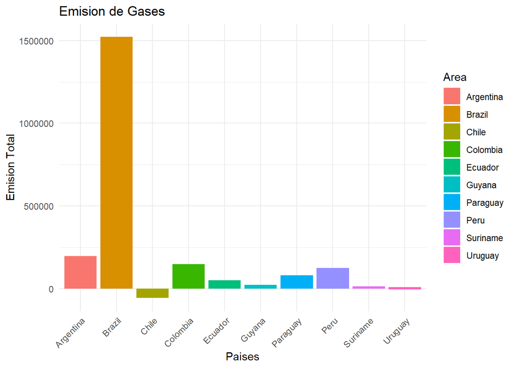

```r
# Gráfico de barras para visualizar el total de emisión
ggplot(df_sudamerica, aes(x = Area, y = total_emission, fill = Area)) +
  geom_bar(stat = "identity", position = "dodge") +
  labs(title = "Emision de Gases",
       x = "Paises",
       y = "Emision Total") +
  theme_minimal() +
  theme(axis.text.x = element_text(angle = 45, hjust = 1))
```

## 3.1 Correlograma

```r
# Ajustar las opciones gráficas
par(mar = c(2, 2, 2, 2) + 0.5)  # Ajusta los márgenes (inferior, izquierdo, superior, derecho)

# Análisis de variables numéricas
num_vars <- df_sudamerica %>% select(where(is.numeric))
cor_matrix <- cor(num_vars, use = "complete.obs")
```

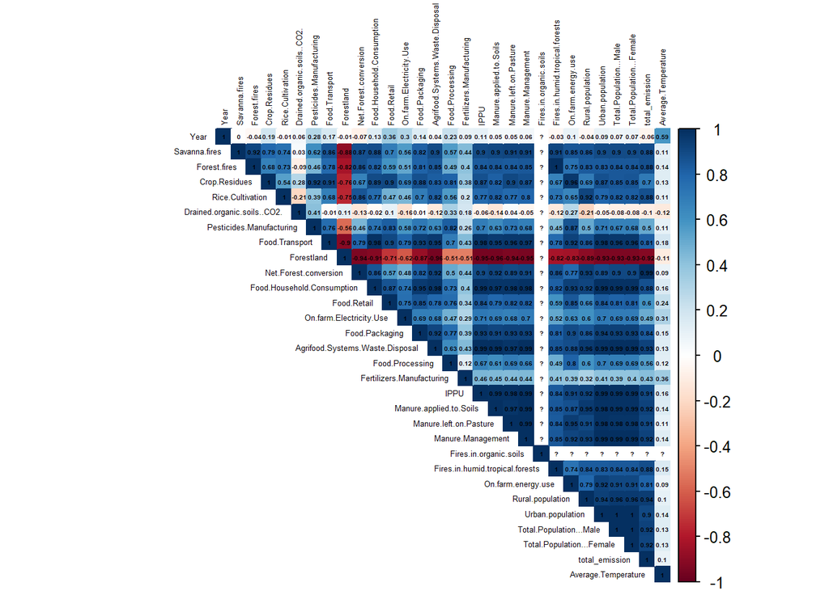

```r
corrplot(cor_matrix, method = "color", type = "upper",
         tl.cex = 0.4, # Tamaño del texto
         tl.col = "black", # Color del texto
         addCoef.col = "black", # Mostrar coeficientes de correlación
         number.cex = 0.3) # Tamaño de los coeficientes
```

# 4. Modelos

## 4.1 Preparacion de data set

### 4.1.1 Escalado

```r
data <- df_sudamerica %>%
  select(where(is.numeric))%>%
  select(-Fires.in.organic.soils,-On.farm.energy.use) #La saque porque son todos ceros
head(data)
```

|  | Year | Savanna.fires | Forest.fires | Crop.Residues | Rice.Cultivation | Drained.organic.soils..CO2. | Pesticides.Manufacturing | Food.Transport | Forestland | Net.Forest.conversion | Food.Household.Consumption | Food.Retail | On.farm.Electricity.Use | Food.Packaging | Agrifood.Systems.Waste.Disposal | Food.Processing | Fertilizers.Manufacturing | IPPU | Manure.applied.to.Soils | Manure.left.on.Pasture | Manure.Management | Fires.in.humid.tropical.forests | Rural.population | Urban.population | Total.Population...Male | Total.Population...Female | total_emission | Average.Temperature |
| --- | --- | --- | --- | --- | --- | --- | --- | --- | --- | --- | --- | --- | --- | --- | --- | --- | --- | --- | --- | --- | --- | --- | --- | --- | --- | --- | --- | --- |
| 1 | 1990 | 2779.692 | 1097.178 | 1965.499 | 914.3008 | 5128.514 | 689 | 2920.126 | -40102.73 | 81523.29 | 3033.822 | 1210.3655 | 152.0622 | 54.0057 | 8503.606 | 2944.795 | 1143.073 | 6469.846 | 952.7475 | 24131.97 | 2173.349 | 541.3267 | 4260175 | 28469564 | 16063515 | 16574141 | 114303.1 | 0.3300833 |
| 2 | 1991 | 2779.692 | 1097.178 | 2144.235 | 676.3176 | 5128.514 | 699 | 3143.701 | -40102.73 | 81523.29 | 2767.644 | 1047.9432 | 177.6963 | 55.4662 | 8798.837 | 2929.310 | 1139.232 | 6707.110 | 923.2520 | 23840.81 | 2148.927 | 541.3267 | 4206419 | 28987499 | 16298168 | 16807594 | 112979.8 | 0.1930833 |
| 3 | 1992 | 2779.692 | 1097.178 | 2248.566 | 1103.0880 | 5128.514 | 631 | 3514.505 | -40102.73 | 81523.29 | 2929.393 | 982.4031 | 138.1414 | 59.0844 | 9051.402 | 2995.283 | 1117.835 | 5164.660 | 914.2624 | 24040.66 | 2184.396 | 541.3267 | 4192854 | 29462297 | 16529209 | 17039077 | 114888.8 | -0.2140833 |
| 4 | 1993 | 2779.692 | 1097.178 | 2235.483 | 1094.8560 | 5128.514 | 571 | 3733.810 | -40102.73 | 81523.29 | 2981.181 | 968.5174 | 126.2214 | 44.9673 | 9272.754 | 2979.677 | 1093.160 | 5427.016 | 958.3982 | 23395.07 | 2177.431 | 541.3267 | 4177901 | 29933016 | 16757748 | 17269492 | 115580.6 | 0.1254167 |
| 5 | 1994 | 2779.692 | 1097.178 | 2233.539 | 1108.1056 | 5128.514 | 693 | 3935.743 | -40102.73 | 81523.29 | 3031.352 | 875.2937 | 137.9826 | 46.6455 | 9486.868 | 2979.677 | 1108.555 | 5737.828 | 1025.7309 | 23504.47 | 2241.324 | 541.3267 | 4160961 | 30397154 | 16989567 | 17499129 | 118040.6 | 0.6264167 |
| 6 | 1995 | 2779.692 | 1097.178 | 2404.908 | 1443.4616 | 5138.312 | 872 | 4168.870 | -40102.73 | 81523.29 | 3128.939 | 866.0811 | 144.7782 | 279.8729 | 9776.670 | 2128.312 | 1102.449 | 5370.535 | 1019.3587 | 23138.20 | 2200.746 | 541.3267 | 4141986 | 30852828 | 17220607 | 17725502 | 118055.0 | 0.2660000 |

```r
# Escalamos las variables númericas, menos la variable predictora
data_scaled = data %>% mutate_at(vars(-total_emission), scale)
head(data_scaled)
```

|  | Year | Savanna.fires | Forest.fires | Crop.Residues | Rice.Cultivation | Drained.organic.soils..CO2. | Pesticides.Manufacturing | Food.Transport | Forestland | Net.Forest.conversion | Food.Household.Consumption | Food.Retail | On.farm.Electricity.Use | Food.Packaging | Agrifood.Systems.Waste.Disposal | Food.Processing | Fertilizers.Manufacturing | IPPU | Manure.applied.to.Soils | Manure.left.on.Pasture | Manure.Management | Fires.in.humid.tropical.forests | Rural.population | Urban.population | Total.Population...Male | Total.Population...Female | total_emission | Average.Temperature |
| --- | --- | --- | --- | --- | --- | --- | --- | --- | --- | --- | --- | --- | --- | --- | --- | --- | --- | --- | --- | --- | --- | --- | --- | --- | --- | --- | --- | --- |
| 1 | -1.674344 | 0.2975738 | -0.09816771 | 0.2299507 | -0.4823964 | 2.548872 | -0.18515878 | -0.037021021 | 0.09574064 | -0.2058032 | 0.017047876 | -0.1121690 | -0.2921740 | -0.5075637 | -0.15447634 | 0.6483765 | -0.2456250 | -0.05533279 | -0.1611332 | 0.4720039 | 0.1310113 | -0.2009971 | -0.2362174 | 0.03298613 | -0.0173039293 | -0.010339044 | 114303.1 | -0.9083073 |
| 2 | -1.562721 | 0.2975738 | -0.09816771 | 0.2976663 | -0.6277716 | 2.548872 | -0.18013796 | 0.003049122 | 0.09574064 | -0.2058032 | -0.037851437 | -0.1667955 | -0.2551103 | -0.5063671 | -0.14101302 | 0.6411838 | -0.2476102 | -0.03838166 | -0.1724849 | 0.4595073 | 0.1233759 | -0.2009971 | -0.2420052 | 0.04470161 | -0.0083388696 | -0.001641946 | 112979.8 | -1.2325462 |
| 3 | -1.451098 | 0.2975738 | -0.09816771 | 0.3371932 | -0.3670732 | 2.548872 | -0.21427951 | 0.069505915 | 0.09574064 | -0.2058032 | -0.004490723 | -0.1888382 | -0.3123018 | -0.5034027 | -0.12949542 | 0.6718275 | -0.2586704 | -0.14858092 | -0.1759447 | 0.4680848 | 0.1344652 | -0.2009971 | -0.2434657 | 0.05544135 | 0.0004881915 | 0.006981762 | 114888.8 | -2.1961904 |
| 4 | -1.339475 | 0.2975738 | -0.09816771 | 0.3322365 | -0.3721018 | 2.548872 | -0.24440441 | 0.108810682 | 0.09574064 | -0.2058032 | 0.006190518 | -0.1935083 | -0.3295366 | -0.5149689 | -0.11940124 | 0.6645785 | -0.2714254 | -0.12983704 | -0.1589584 | 0.4403763 | 0.1322876 | -0.2009971 | -0.2450757 | 0.06608882 | 0.0092196621 | 0.015565681 | 115580.6 | -1.3926934 |
| 5 | -1.227852 | 0.2975738 | -0.09816771 | 0.3314998 | -0.3640081 | 2.548872 | -0.18315045 | 0.145001936 | 0.09574064 | -0.2058032 | 0.016538294 | -0.2248617 | -0.3125314 | -0.5135940 | -0.10963707 | 0.6645785 | -0.2634673 | -0.10763135 | -0.1330445 | 0.4450716 | 0.1522633 | -0.2009971 | -0.2468996 | 0.07658743 | 0.0180764471 | 0.024120618 | 118040.6 | -0.2069731 |
| 6 | -1.116229 | 0.2975738 | -0.09816771 | 0.3964248 | -0.1591514 | 2.555040 | -0.09327784 | 0.186783757 | 0.09574064 | -0.2058032 | 0.036665648 | -0.2279602 | -0.3027058 | -0.3225100 | -0.09642136 | 0.2691342 | -0.2666236 | -0.13387232 | -0.1354969 | 0.4293513 | 0.1395769 | -0.2009971 | -0.2489426 | 0.08689459 | 0.0269034700 | 0.032553956 | 118055.0 | -1.0599738 |

```r
# Elimino registros nulos
sum(is.na(data_scaled))
```

```
## [1] 0
```

```r
data_scaled_na <- na.omit(data_scaled)
```

### 4.1.2 Dataset Train y Test

```r
# Definir 'y' como la columna de la variable objetivo
y <- data_scaled_na[["total_emission"]]

# Definir 'X' como una matriz de las variables predictoras
X <- as.matrix(data_scaled_na[, -which(names(data_scaled_na) == "total_emission")])
```

```r
# Dividir los datos en entrenamiento y prueba (70% entrenamiento, 30% prueba)
set.seed(42)  # Para reproducibilidad
trainIndex <- createDataPartition(y, p = 0.7, list = FALSE)
X_train <- X[trainIndex, ]
y_train <- y[trainIndex]
X_test <- X[-trainIndex, ]
y_test <- y[-trainIndex]
```

## 4.2 Modelo LARS

La función cv.lars en R realiza una validación cruzada para el modelo LARS (Least Angle Regression) o LASSO, dependiendo del tipo de ajuste seleccionado. En este caso, se utiliza con los parámetros type = “lar” y mode = “step”.

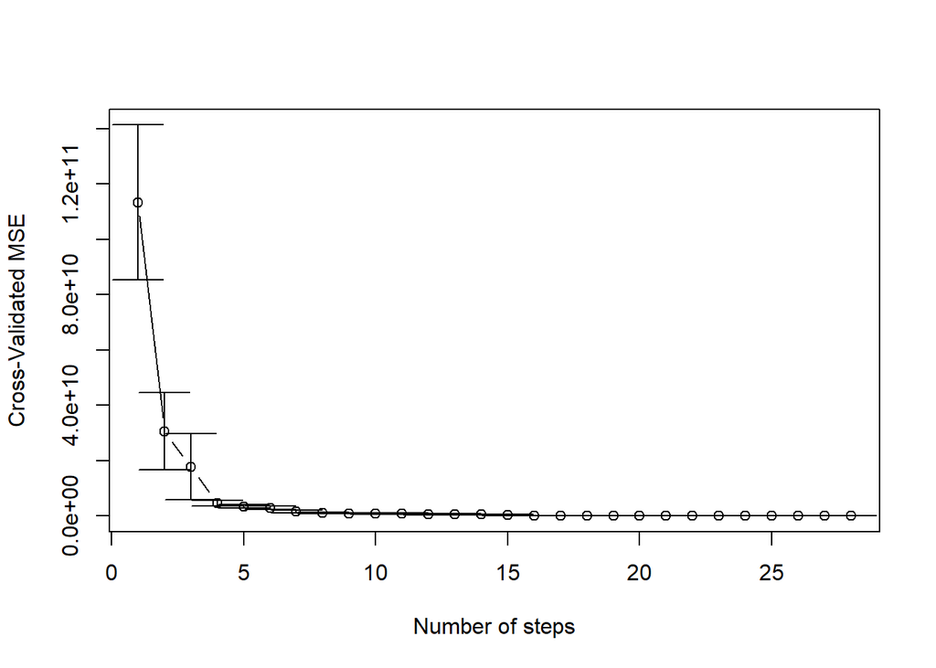

```r
# Usando cv.lars sin el argumento index
cv_lars=cv.lars(X_train,y_train, K = 10, trace = FALSE, plot.it = TRUE, se = TRUE, type = "lar", mode = "step", normalize = F)
```

### 4.2.1 Ajuste del Modelo

```r
# Ahora ajustamos el modelo LARS
modelo_lars <- lars(X_train, y_train, type = "lar", normalize = F) # "lar" selecciona el tipo de regularización
```

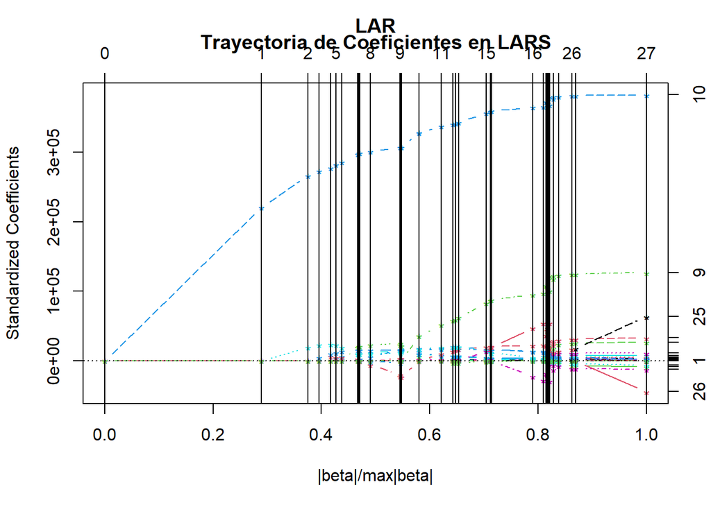

```r
# Evaluación del modelo
# Visualizar los coeficientes a lo largo del proceso de ajuste
plot(modelo_lars)
title("Trayectoria de Coeficientes en LARS")
```

```r
# Extraer coeficientes
coeficientes_beta <- coef(modelo_lars)
```

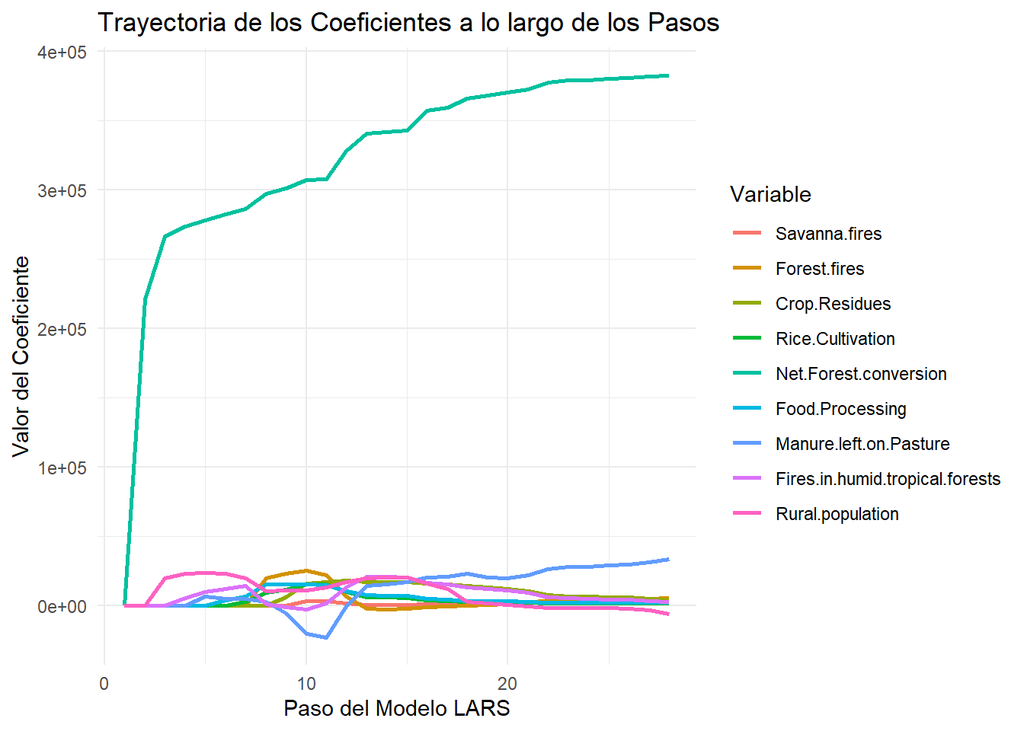

```r
coef_long <- melt(coeficientes_beta, id.vars = "step")

# Asumiendo que tu dataframe en formato largo se llama coef_long
variables_positivas_step_10 <- coef_long %>%
  filter(Var1 == 10, value != 0) %>%
  select(Var2)  # Selecciona solo las variables

# Crear una lista de nombres de las variables
variables_list <- unique(variables_positivas_step_10$Var2)

# Filtrar coef_long para incluir solo las variables en variables_list
datos_filtrados <- coef_long %>%
  dplyr::filter(Var2 %in% variables_list)

# Cargar ggplot2
ggplot(datos_filtrados, aes(x = Var1, y = value, color = Var2)) +
  geom_line(linewidth = 1) +  # Usar linewidth en lugar de size
  labs(title = "Trayectoria de los Coeficientes a lo largo de los Pasos",
       x = "Paso del Modelo LARS",
       y = "Valor del Coeficiente",
       color = "Variable") +
  theme_minimal() +
  theme(legend.position = "right")  # Ajustar la posición de la leyenda
```

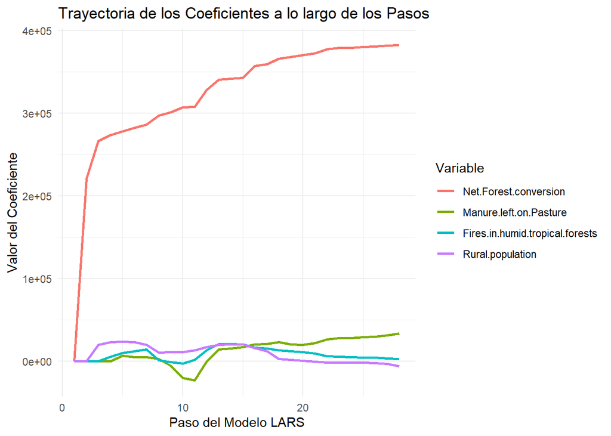

```r
coef_long <- melt(coeficientes_beta, id.vars = "step")

# Asumiendo que tu dataframe en formato largo se llama coef_long
variables_positivas_step_5 <- coef_long %>%
  filter(Var1 == 5, value != 0) %>%
  select(Var2)  # Selecciona solo las variables

# Crear una lista de nombres de las variables
variables_list <- unique(variables_positivas_step_5$Var2)

# Filtrar coef_long para incluir solo las variables en variables_list
datos_filtrados <- coef_long %>%
  dplyr::filter(Var2 %in% variables_list)

# Cargar ggplot2
ggplot(datos_filtrados, aes(x = Var1, y = value, color = Var2)) +
  geom_line(linewidth = 1) +  # Usar linewidth en lugar de size
  labs(title = "Trayectoria de los Coeficientes a lo largo de los Pasos",
       x = "Paso del Modelo LARS",
       y = "Valor del Coeficiente",
       color = "Variable") +
  theme_minimal() +
  theme(legend.position = "right")  # Ajustar la posición de la leyenda
```

### 4.4 Predicciones

```r
# Realizar predicciones en el conjunto de prueba
y_pred <- predict(modelo_lars, X_test)
```

```r
y_pred_lars_step1 <- y_pred$fit[, 1]
y_pred_lars_step2 <-y_pred$fit[, 2]
y_pred_lars_step3 <-y_pred$fit[, 3]
y_pred_lars_step4 <- y_pred$fit[, 4]
y_pred_lars_step5 <- y_pred$fit[, 5]
y_pred_lars_step6 <- y_pred$fit[, 6]
y_pred_lars_step7 <- y_pred$fit[, 7]
y_pred_lars_step8 <- y_pred$fit[, 8]
y_pred_lars_step9 <- y_pred$fit[, 9]
y_pred_lars_step10 <- y_pred$fit[, 10]
y_pred_lars_step11 <- y_pred$fit[, 11]
y_pred_lars_step12 <- y_pred$fit[, 12]
y_pred_lars_step13 <- y_pred$fit[, 13]
y_pred_lars_step14 <- y_pred$fit[, 14]
y_pred_lars_step15 <- y_pred$fit[, 15]
y_pred_lars_full <- y_pred$fit[, ncol(y_pred$fit)] # Extraer la tercer columna columna
```

```r
# Evaluar el rendimiento del modelo utilizando MSE
# Crear un vector con los nombres de los pasos
steps <- c("Paso 1", "Paso 2", "Paso 3", "Paso 4", "Paso 5", "Paso 6",
           "Paso 7", "Paso 8", "Paso 9", "Paso 10", "Paso 11", "Paso 12", "Paso 13", "Paso 14","Paso 15","Modelo completo")

# Calcular los valores de MSE para cada paso
mse_values <- c(mean((y_test - y_pred_lars_step1)^2),
                mean((y_test - y_pred_lars_step2)^2),
                mean((y_test - y_pred_lars_step3)^2),
                mean((y_test - y_pred_lars_step4)^2),
                mean((y_test - y_pred_lars_step5)^2),
                mean((y_test - y_pred_lars_step6)^2),
                mean((y_test - y_pred_lars_step7)^2),
                mean((y_test - y_pred_lars_step8)^2),
                mean((y_test - y_pred_lars_step9)^2),
                mean((y_test - y_pred_lars_step10)^2),
                mean((y_test - y_pred_lars_step11)^2),
                mean((y_test - y_pred_lars_step12)^2),
                mean((y_test - y_pred_lars_step13)^2),
                mean((y_test - y_pred_lars_step14)^2),
                mean((y_test - y_pred_lars_step15)^2),
                mean((y_test - y_pred_lars_full)^2))

# Crear un data frame con los resultados
table_mse <- data.frame(Paso = steps, MSE = mse_values)

# Mostrar la tabla
print(table_mse)
```

```
##               Paso          MSE
## 1           Paso 1 1.634557e+11
## 2           Paso 2 2.380122e+10
## 3           Paso 3 7.078333e+09
## 4           Paso 4 4.753421e+09
## 5           Paso 5 2.898969e+09
## 6           Paso 6 2.310868e+09
## 7           Paso 7 1.793601e+09
## 8           Paso 8 8.900085e+08
## 9           Paso 9 7.948454e+08
## 10         Paso 10 7.276757e+08
## 11         Paso 11 7.218755e+08
## 12         Paso 12 3.409791e+08
## 13         Paso 13 1.823757e+08
## 14         Paso 14 1.721788e+08
## 15         Paso 15 1.586903e+08
## 16 Modelo completo 6.646559e+05
```

```r
# Calcular el R²
actual <- y_test  # Valores reales
mean_actual <- mean(actual)  # Media de los valores reales

# Calcular la suma de los errores cuadrados y la suma total de los cuadrados
ss_residual <- sum((actual - y_pred_lars_step11)^2)  # Error cuadrático residual
ss_total <- sum((actual - mean_actual)^2)  # Suma total de los cuadrados

# Calcular R²
r_squared <- 1 - (ss_residual / ss_total)
print(paste("El R² es:", r_squared))
```

```
## [1] "El R² es: 0.995530534677552"
```

```r
# Calcular el R²
actual <- y_test  # Valores reales
mean_actual <- mean(actual)  # Media de los valores reales

# Calcular la suma de los errores cuadrados y la suma total de los cuadrados
ss_residual <- sum((actual - y_pred_lars_step6)^2)  # Error cuadrático residual
ss_total <- sum((actual - mean_actual)^2)  # Suma total de los cuadrados

# Calcular R²
r_squared <- 1 - (ss_residual / ss_total)
print(paste("El R² es:", r_squared))
```

```
## [1] "El R² es: 0.985692349798668"
```

```r
# Calcular el R²
actual <- y_test  # Valores reales
mean_actual <- mean(actual)  # Media de los valores reales

# Calcular la suma de los errores cuadrados y la suma total de los cuadrados
ss_residual <- sum((actual - y_pred_lars_step2)^2)  # Error cuadrático residual
ss_total <- sum((actual - mean_actual)^2)  # Suma total de los cuadrados

# Calcular R²
r_squared <- 1 - (ss_residual / ss_total)
print(paste("El R² es:", r_squared))
```

```
## [1] "El R² es: 0.852635615916888"
```

## 4.3 Modelo LASSO

```r
#Entrenar el modelo
modelo_lasso <- glmnet(X_train, y_train, alpha = 1, standardize = F) #alpha 1 es Lasso y alpha 0 es Ridge

# aplicamos la función tidy para obtener los coeficientes del modelo
lasso_coef = modelo_lasso %>% tidy() %>% arrange(step)
lasso_coef
```

| term | step | estimate | lambda | dev.ratio |
| --- | --- | --- | --- | --- |
| (Intercept) | 1 | 1.554243e+05 | 309112.8967 | 0.0000000 |
| (Intercept) | 2 | 1.566961e+05 | 281652.1589 | 0.1677206 |
| Net.Forest.conversion | 2 | 3.178040e+04 | 281652.1589 | 0.1677206 |
| (Intercept) | 3 | 1.578548e+05 | 256630.9574 | 0.3069652 |
| Net.Forest.conversion | 3 | 6.073752e+04 | 256630.9574 | 0.3069652 |
| (Intercept) | 4 | 1.589107e+05 | 233832.5704 | 0.4225685 |
| Net.Forest.conversion | 4 | 8.712217e+04 | 233832.5704 | 0.4225685 |
| (Intercept) | 5 | 1.598727e+05 | 213059.5293 | 0.5185444 |
| Net.Forest.conversion | 5 | 1.111629e+05 | 213059.5293 | 0.5185444 |
| (Intercept) | 6 | 1.607492e+05 | 194131.9080 | 0.5982252 |

[output cut: 451 more lines]

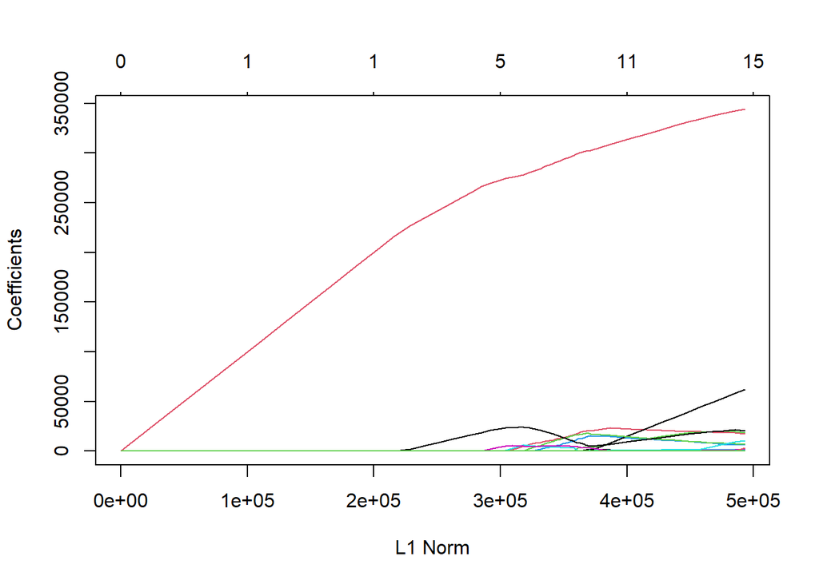

```r
plot(modelo_lasso)
```

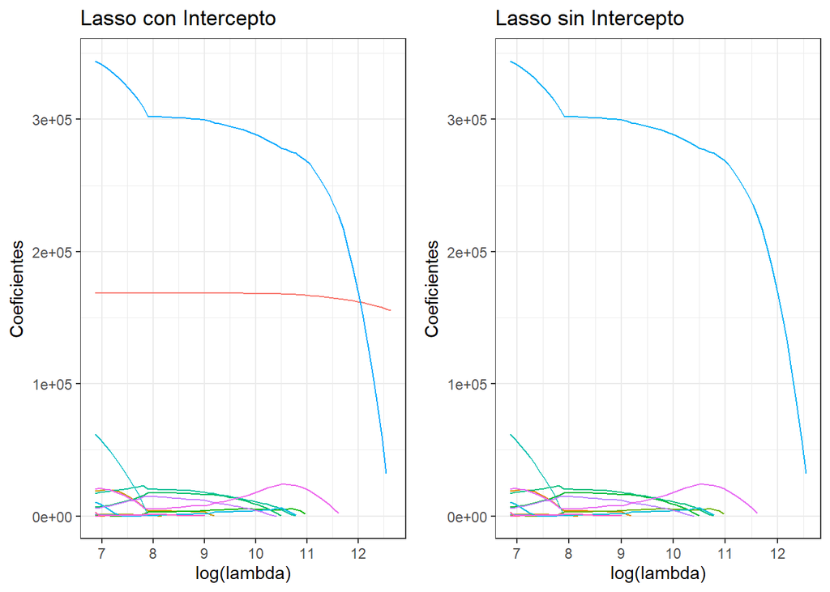

```r
# Gráfico de coeficientes en función del lambda con intercepto
g1 = lasso_coef  %>%
  ggplot(., aes(log(lambda), estimate, group=term, color=term)) +
  geom_line() +
  theme_bw()  +
  theme(legend.position = 'none') +
  labs(title="Lasso con Intercepto",  y="Coeficientes")
# Gráfico de coeficientes en función del lambda sin intercepto
g2 = lasso_coef %>%
  filter(term!='(Intercept)') %>%
  ggplot(., aes(log(lambda), estimate, group=term, color=term)) +
  geom_line() +
  theme_bw()  +
  theme(legend.position = 'none') +
  labs(title="Lasso sin Intercepto", y="Coeficientes")
# armamos la grilla con ambos gráficos
plot_grid(g1,g2)
```

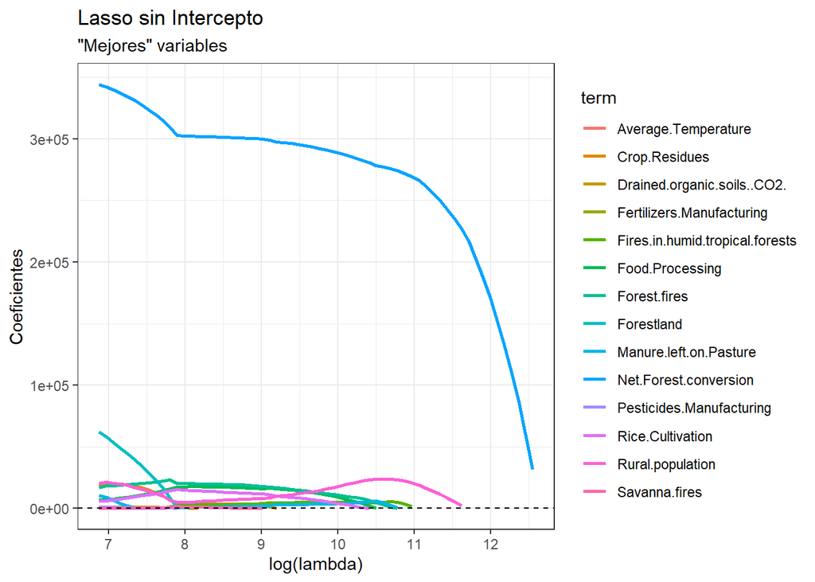

```r
# Seleccionamos los terminos que sobreviven para valores altos de lambda
terminos_sobrevientes = lasso_coef %>%
  filter(log(lambda)>7, term != "(Intercept)") %>%
  select(term) %>%
  distinct() %>%
  pull()
# Graficamos
lasso_coef %>% filter(term %in% terminos_sobrevientes) %>%
  ggplot(., aes(log(lambda), estimate, group=term, color=term)) +
  geom_line(size=1) +
  geom_hline(yintercept = 0, linetype='dashed') +
  theme_bw() +
  labs(title="Lasso sin Intercepto", y="Coeficientes", subtitle= "\"Mejores\" variables")
```

```r
# Validación el modelo Lasso para elegir lambda óptimo
cv_modelo_lasso <- cv.glmnet(X_train, y_train, alpha = 1, standardize = F)# alpha = 1 para Lasso
```

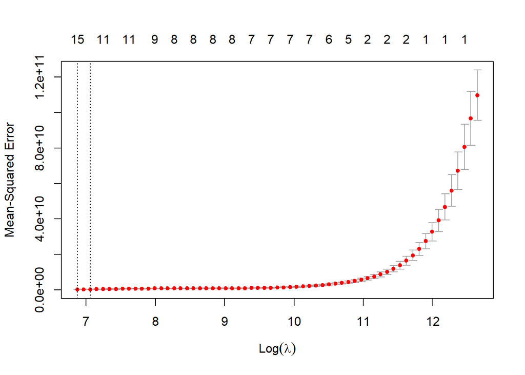

```r
plot(cv_modelo_lasso)
```

El gráfico nos muestra la media del MSE con su límite superior e inferior y la cantidad de variables que sobreviven para cada valor de lambda.

```r
# Información de CV en dataframe con tidy
cv_modelo_lasso %>% tidy()
```

| lambda | estimate | std.error | conf.low | conf.high | nzero |
| --- | --- | --- | --- | --- | --- |
| 309112.8967 | 109738373286 | 14211553865 | 95526819421 | 123949927152 | 0 |
| 281652.1589 | 96696879748 | 15252681898 | 81444197851 | 111949561646 | 1 |
| 256630.9574 | 80602346261 | 12780504103 | 67821842158 | 93382850364 | 1 |
| 233832.5704 | 67162936180 | 10661093995 | 56501842185 | 77824030174 | 1 |
| 213059.5293 | 56006644666 | 8897072861 | 47109571805 | 64903717528 | 1 |
| 194131.9080 | 46753291225 | 7426601143 | 39326690082 | 54179892368 | 1 |
| 176885.7643 | 39080723165 | 6200670898 | 32880052267 | 45281394063 | 1 |
| 161171.7205 | 32720745114 | 5181689837 | 27539055277 | 37902434951 | 1 |
| 146853.6691 | 27446555196 | 4334681782 | 23111873414 | 31781236978 | 1 |
| 133807.5939 | 23062860260 | 3629072503 | 19433787758 | 26691932763 | 1 |

[output cut: 53 more lines]

```r
cv_modelo_lasso %>% glance()
```

| lambda.min | lambda.1se | nobs |
| --- | --- | --- |
| 966.1991 | 1163.79 | 218 |

```r
# Selección lambda óptimo
lasso_lambda_opt = cv_modelo_lasso$lambda.min
# Entrenamiento modelo óptimo
lasso_opt = glmnet(X_train, y_train, alpha = 1, standardize = F, # Estandarizamos
                   lambda = lasso_lambda_opt)
# Salida estandar
lasso_opt
```

```
##
## Call:  glmnet(x = X_train, y = y_train, alpha = 1, lambda = lasso_lambda_opt,      standardize = F)
##
##   Df  %Dev Lambda
## 1 14 99.91  966.2
```

```r
lasso_opt %>% tidy()
```

| term | step | estimate | lambda | dev.ratio |
| --- | --- | --- | --- | --- |
| (Intercept) | 1 | 1.685694e+05 | 966.1991 | 0.9991243 |
| Savanna.fires | 1 | 2.086196e+02 | 966.1991 | 0.9991243 |
| Crop.Residues | 1 | 1.415900e+04 | 966.1991 | 0.9991243 |
| Rice.Cultivation | 1 | 4.626264e+03 | 966.1991 | 0.9991243 |
| Drained.organic.soils..CO2. | 1 | 1.705882e+03 | 966.1991 | 0.9991243 |
| Pesticides.Manufacturing | 1 | 2.093281e+03 | 966.1991 | 0.9991243 |
| Forestland | 1 | 6.435788e+04 | 966.1991 | 0.9991243 |
| Net.Forest.conversion | 1 | 3.423945e+05 | 966.1991 | 0.9991243 |
| Food.Processing | 1 | 6.903186e+03 | 966.1991 | 0.9991243 |
| Fertilizers.Manufacturing | 1 | 3.831223e+02 | 966.1991 | 0.9991243 |

[output cut: 5 more lines]

han quedado 14 variables y el modelo explica el 99% de la deviance

```r
# Predecir con el modelo Lasso optimo
y_pred_lasso <- predict(lasso_opt, X_test)

# Evaluar el modelo Lasso
mse_lasso <- mean((y_test - y_pred_lasso)^2)
r2_lasso <- 1 - sum((y_test - y_pred_lasso)^2) / sum((y_test- mean(y_test))^2)

print(paste("MSE Lasso: ", mse_lasso))
```

```
## [1] "MSE Lasso:  146567982.766253"
```

```r
print(paste("R² Lasso: ", r2_lasso))
```

```
## [1] "R² Lasso:  0.99909252980433"
```